## Ivestigating ways to Efficiently Foster Healthy Learning Enviorments in Schools

# Project 1

## 1.1 Introduction

In the United States, many high school students take a standardized test when applying to college, one of which is the SAT. The scores range from 600 to 2400, with a higher score being more desirable. The SAT is one of the most critical factors in college admissions. This study aims to investigate school traits that may contribute to student health and explore non-academic methods to enhance SAT score performance in under performing schools.

Unlike typical public high schools, NYC public high schools have admissions processes that permit them to shape their incoming student body, as opposed to traditional high schools where the intake is determined by local middle school zoning. Variations in school environments could potentially improve mental and physical health, which may positively influence SAT scores. This research is inspired by listening to health and habit podcasts, particularly by Stanford neuroscientist Andrew Huberman. This study will focus on school characteristics that may passively implement some of Huberman's suggestions to observe if SAT scores are affected. The goal is to find and discuss some passive and economically efficient strategies that schools can implement to improve the educational and academic achievement of their students.

Huberman's podcast emphasizes the significant mood enhancements from morning sunlight exposure. As the quality of morning light varies with wake-up times, influenced by school start times, this factor could conceivably impact SAT performance. Blume, C., Garbazza, C., \& Spitschan, M. (2019) discuss the critical effects of light on human circadian rhythms, sleep, and mood, highlighting light's potential impact on academic success. This study seeks to identify an optimal start time that could bolster student performance by leveraging the natural benefits of morning light. Studies by Song, C., Ikei, H., \& Miyazaki, Y. (2016), and Kuo, F. E., \& Taylor, A. F. (2004), present evidence of improved performance with exposure to nature. Purtell, K. M., \& Gershoff, E. T. (2015) found that fiber consumption enhances teen performance. Lau, Y. (2022) provides evidence of the benefits of diversity, which will be examined using an HHI diversity score which will be talked about in depth later. Berding, K., Carbia, C., \& Cryan, J. F. (2021) also report the advantages of fiber intake. I can measure fiber intake by the number of salad bars per lunch served. Finally, Bayar, A., \& Karaduman, H. A. (2021) conclude that extracurricular activities boost academic success. Larger schools have the resources and student population to support numerous clubs and extracurricular activities. However, (Ramchander and Naude 2018) fail to draw the same conclusion in a university study that took place in South Africa. Taken together, these studies propose approaches to improve student performance, indicating that modifications to school environments and incorporating factors that enhance student well-being could be advantageous.

Overall the papers are in studies of controlled environments. The difference in my research is that it is directly talking about high schools and student achievement through SAT scores. We are looking at real life applications here.

I will use datasets sourced from New York City's 2015 Street Tree Census, school food reports, and fast-food restaurant data. Based on the literature reviewed, it is believed that slight improvements in SAT scores should be observed in schools with more salad bars, more trees, and fewer fast-food restaurants nearby.

The overall findings of my research suggest that the anticipated health-improving factors did not yield the expected outcomes. However, diversity, larger school enrollments, and earlier start times do seem to play a positive, significant role in academic achievement. In our analysis, we will start by looking at the data, followed by initial findings and, lastly, our regression results.

```python
import random
import numpy as np
import pandas as pd
import qeds
import matplotlib.pyplot as plt
import matplotlib.pyplot as plt
import seaborn as sns
from scipy.optimize import curve_fit
import matplotlib.colors as mcolors
import geopandas as gpd
from shapely.geometry import Point
%matplotlib inline
import folium
import warnings
import glob
warnings.filterwarnings("ignore")
import requests
import matplotlib.patches as mpatches
from geopy.distance import geodesic
import ssl
ssl._create_default_https_context = ssl._create_unverified_context
from tqdm import tqdm
import statsmodels.api as sm
from statsmodels.iolib.summary2 import summary_col
from linearmodels.iv import IV2SLS
from statsmodels.iolib.summary2 import summary_col
from stargazer.stargazer import Stargazer
from IPython.core.display import HTML
```

```python
import os

# Print the current working directory
#current_working_directory = os.getcwd()
#print(f"The current working directory is: {current_working_directory}")

# Print the list of files in the current working directory
#files_in_cwd = os.listdir(current_working_directory)
#print("Files and directories in the current working directory:")
#print(files_in_cwd)
```

## 1.2 Data Cleaning/Loading

```python
scores_df = pd.read_csv('../Data/scores.csv')

restaurants_df = pd.read_csv('../Data/FastFoodRestaurants.csv')
trees_df = pd.read_csv('../Data/2015-street-tree-census-tree-data.csv')
school_food_df = pd.read_csv('../Data/nycdoe-schoolfood-fy18-report-to-city-council-detail-final.csv')
try:
    income_df = pd.read_csv('../Data/kaggle_income.csv', encoding='latin1')
except UnicodeDecodeError:
    try:
        income_df = pd.read_csv('../Data/kaggle_income.csv', encoding='cp1252')
    except UnicodeDecodeError:
        income_df = pd.read_csv('../Data/kaggle_income.csv', encoding='utf-8-sig')
```

```python
def to_numeric_if_string(df, column):
    if df[column].dtype == 'object':
        df[column] = pd.to_numeric(df[column].str.replace('%', ''), errors='coerce') / 100
    elif df[column].dtype in ['float64', 'int64']:
        df[column] = df[column] / 100

scores_df['Percent Tested'] = scores_df['Percent Tested'].str.replace('%', '').astype(float) *100
# Calculate the 'School Day Length' in hours
# Define a function to convert time to datetime, handling NaN values
def convert_time(time_series):
    return pd.to_datetime(time_series, format='%I:%M %p', errors='coerce')

# Apply the function to the 'Start Time' and 'End Time' columns
scores_df['Start Time'] = convert_time(scores_df['Start Time'])
scores_df['End Time'] = convert_time(scores_df['End Time'])

# Calculate 'School Day Length' in hours, while handling NaN values
scores_df['School Day Length'] = (scores_df['End Time'] - scores_df['Start Time']).dt.total_seconds() / 3600

# Show the result and any NaNs in 'School Day Length'
scores_df[['Start Time', 'End Time', 'School Day Length']].head()

scores_df['Start Time Hour'] = scores_df['Start Time'].dt.hour + scores_df['Start Time'].dt.minute / 60
scores_df['End Time Hour'] = scores_df['End Time'].dt.hour + scores_df['End Time'].dt.minute / 60

# Cleaning the data
# Dropping the rows <= 0 values for 'School Day Length'
scores_df = scores_df[scores_df['School Day Length'] > 0]
scores_df = scores_df.dropna(subset=['Average Score (SAT Math)', 'Average Score (SAT Reading)', 'Average Score (SAT Writing)'])


# Calculate the total SAT score
scores_df['Average Total SAT Score'] = scores_df['Average Score (SAT Math)'] + scores_df['Average Score (SAT Reading)'] + scores_df['Average Score (SAT Writing)']


def calculate_range(series):
    return series.max() - series.min()



percent_columns = ['Percent White', 'Percent Black', 'Percent Hispanic', 'Percent Asian', 'Percent Tested']
for col in percent_columns:
    to_numeric_if_string(scores_df, col)

def hhi(row):
    values = [row['Percent White'], row['Percent Black'], row['Percent Hispanic'], row['Percent Asian']]
    return sum((x**2) for x in values if pd.notnull(x))

scores_df['HHI'] = scores_df.apply(hhi, axis=1) * 10

def to_24hr_time(decimal_hour):
    hours = int(decimal_hour)
    minutes = int((decimal_hour - hours) * 60)
    return f'{str(hours).zfill(2)}:{str(minutes).zfill(2)}'

# Apply the function to the 'Start Time Hour' column
scores_df['Start Time Hours'] = scores_df['Start Time Hour'].apply(to_24hr_time)
scores_df['Start Time Hours'] #ok but I can't seem to use it on my graph in part 2.1 or in my summary table like in project 1.
#I went to colab hour and got it in float form.
```

```
2      08:15
3      08:00
4      08:30
5      08:00
6      08:30
       ...
430    07:45
431    08:45
432    08:15
433    08:30
434    08:45
Name: Start Time Hours, Length: 374, dtype: object
```

# 1.3 Summary Statistics Table

```python
# Calculate summary statistics for relevant columns
summary_stats = scores_df[['Average Total SAT Score', 'School Day Length', 'Percent Tested', 'HHI', 'Student Enrollment', 'Start Time Hour']].describe()
summary_stats.loc['range'] = summary_stats.loc['max'] - summary_stats.loc['min']


# Rename the 'calculate_range' function name in the output to 'range'
summary_stats.rename(columns={'calculate_range': 'range'}, inplace=True)

# Display the summary statistics table
print(summary_stats)
```

```
       Average Total SAT Score  School Day Length  Percent Tested         HHI  \
count               374.000000         374.000000      374.000000  374.000000
mean               1275.347594           7.026693       64.735294    4.988173
std                 194.866056           0.512721       18.860023    1.605588
min                 924.000000           5.916667       18.500000    2.072070
25%                1157.000000           6.750000       50.725000    3.743278
50%                1226.000000           7.000000       63.800000    4.724715
75%                1327.000000           7.325000       79.500000    5.822963
max                2144.000000           9.000000      100.000000   10.000000
range              1220.000000           3.083333       81.500000    7.927930

       Student Enrollment  Start Time Hour
count          374.000000       374.000000
mean           756.459893         8.275134
std            774.287044         0.370949
min            142.000000         7.250000
25%            397.250000         8.000000
50%            482.500000         8.250000
75%            660.500000         8.500000
max           5447.000000         9.833333
range         5305.000000         2.583333
```

For data cleaning, I have deleted rows with missing SAT scores as that is the Y value which is central to the question.

To measure the time per day spent in school, a 'School day length' column was created by subtracting the start time from the end time of the schools.

To interpret the summary table: "Mean" refers to the average value, "Min" stands for the minimum value, and "Max" represents the maximum value. "Std" indicates the standard deviation, which measures the spread of the data around the mean. The interquartile range (IQR) is the difference between the 25th (lower quartile) and 75th percentiles (upper quartile), showing the middle 50% of the data. "Range" is the difference between the max and min values. The "50%" value is the median, or the midpoint of the data.

The summary statistics reveal that after data cleaning, we are working with 374 schools, a relatively small sample. The average SAT score of 1275.35 points to moderate to high performance across these schools, with a significant standard deviation of 194.87 indicating wide variability in scores. Aside from "School Day Length," the large standard deviations and interquartile across our variables suggest diverse data rather than concentration within narrow ranges. "School Day Length" averages slightly over 7 hours, but the range shows notable differences in school day durations. HHI scores have a decent interquartile range and a standard deviation of 1.6, which is a good characteristic to warrant exploration of the variable. I have made the diversity score out of 10 instead of decimals for clarity. Start Time Hour is an interesting variable too. I can see that most schools start between 8AM and 8:30 am. The standard deviation sugests that we cna explore further than the interquartile range. Student enrollment values were less than I expected, so there are many schools that are around 500 in size. However, with a large standard deviation of 774, there seems to be a good number of schools that are much larger than the average. Overall, these summary statistics show that the data looks promising for deeper analysis with these X-values.

# 1.4 Plots, Histograms, Figures

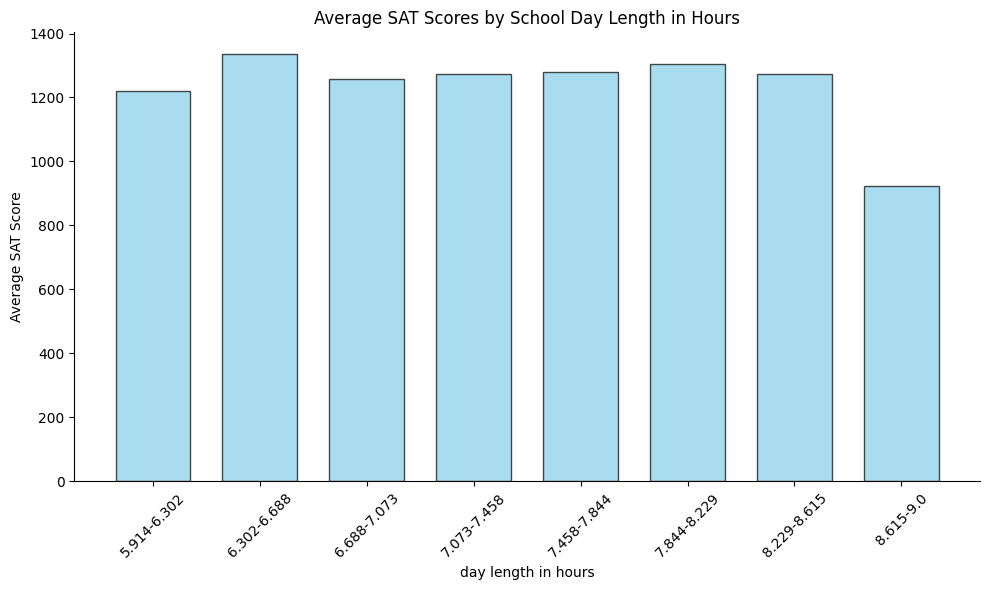

```python
# Create bins for 'Student Enrollment'
student_bins = pd.cut(scores_df['School Day Length'], bins=8)

# Grouping by the bins
binned_avg_sat = scores_df.groupby(student_bins)['Average Total SAT Score'].mean()

#edges of each bin for labeling
bin_edges = student_bins.cat.categories


plt.figure(figsize=(10, 6))
plt.bar(range(len(binned_avg_sat)), binned_avg_sat, width=.7, alpha=0.7, color='skyblue', edgecolor='black')

# title and main lables
plt.title('Average SAT Scores by School Day Length in Hours')
plt.xlabel('day length in hours')
plt.ylabel('Average SAT Score')

# Labels
plt.xticks(ticks=np.arange(len(bin_edges)), labels=[f"{(edge.left)}-{(edge.right)}" for edge in bin_edges], rotation=45)
ax = plt.gca()
ax.spines['right'].set_visible(False)
ax.spines['top'].set_visible(False)

plt.tight_layout()  # Adjust the layout to make room for the x-axis labels
plt.show()
```

Above, we have a bar graph of school day lengths on the x-axis and SAT scores on the y-axis. Interestingly, the graph appears quite uniform, and there is no clear positive or negative correlation. This contradicts my prediction, as I expected school day length to be positively associated with SAT scores. This is because more time in school means more time to learn, which should imply better test results. Based off this graph, it seems that one of these implications is missing.

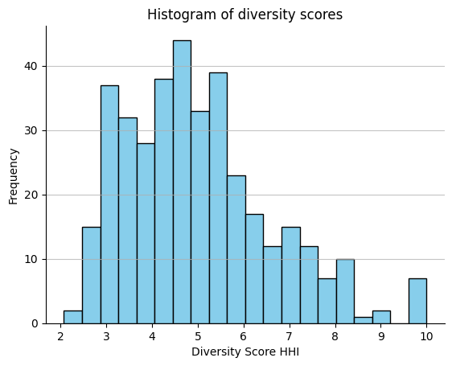

```python
plt.hist(scores_df['HHI'].dropna(), bins=20, color='skyblue', edgecolor='black')
plt.title('Histogram of diversity scores')
plt.xlabel('Diversity Score HHI')
plt.ylabel('Frequency')
plt.grid(axis='y', alpha=0.75)
ax = plt.gca()
ax.spines['right'].set_visible(False)
ax.spines['top'].set_visible(False)
plt.show()
```

The histogram displayed above represents the distribution of diversity scores, measured by the Herfindahl-Hirschman Index (HHI), across various schools. It is observed that a substantial number of schools fall within the diversity score range of 3 to 6. This concentration of data within this range indicates that there is a sufficient sample size to analyze the impact of diversity on academic performance, specifically how a diverse environment may influence SAT scores. This analysis aligns with our research question on whether diversity can improove accademic outcomes.

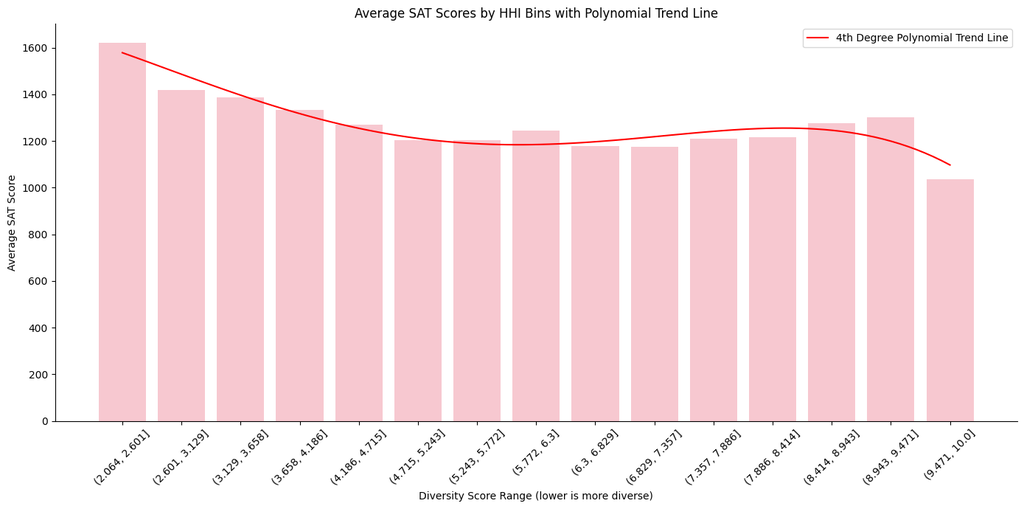

```python
bins = pd.cut(scores_df['HHI'], bins=15)
# Create range labels for each bin
bin_ranges = [f"{round(bin_.left, 2)}-{round(bin_.right, 2)}" for bin_ in bins.cat.categories]

# Map the HHI values to the bin ranges for plotting
scores_df['HHI Bin Range'] = pd.cut(scores_df['HHI'], bins=bins.cat.categories, labels=bin_ranges)

# Group by the bin ranges to get the average SAT scores
grouped = scores_df.groupby('HHI Bin Range')['Average Total SAT Score'].mean().reset_index()

# Fit a 4th degree polynomial to the binned data
coefs = np.polyfit(range(len(grouped)), grouped['Average Total SAT Score'], 4)
poly = np.poly1d(coefs)

# Generate a sequence of x values for plotting the trend line
x_trend = np.linspace(0, len(grouped) - 1, 100)

# Calculate the y values from the polynomial trend line
y_trend = poly(x_trend)

# Plot the bar plot
plt.figure(figsize=(14, 7))
barplot = sns.barplot(x='HHI Bin Range', y='Average Total SAT Score', data=grouped, color='pink')

# Plotting the polynomial trend line onto the bar plot
plt.plot(x_trend, y_trend, color='red', label='4th Degree Polynomial Trend Line')

# Set plot labels and title
plt.xlabel('Diversity Score Range (lower is more diverse)')
plt.ylabel('Average SAT Score')
plt.title('Average SAT Scores by HHI Bins with Polynomial Trend Line')
plt.legend()
plt.xticks(ticks=np.arange(len(grouped)), labels=grouped['HHI Bin Range'], rotation=45)
ax = plt.gca()
ax.spines['right'].set_visible(False)
ax.spines['top'].set_visible(False)
plt.tight_layout()
plt.show()
```

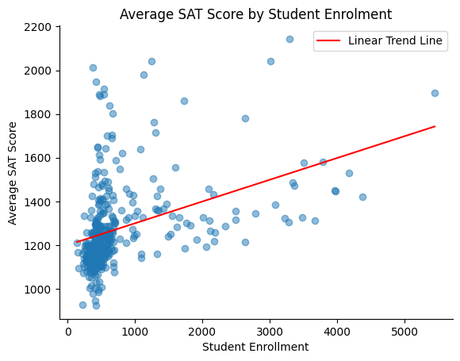

```python
plt.scatter(scores_df['Student Enrollment'], scores_df['Average Total SAT Score'], alpha=0.5)

# Fit a polynomial of degree 3 (cubic) to the data
# Change the degree to fit the complexity of your data
degree = 1

coefficients = np.polyfit(scores_df['Student Enrollment'], scores_df['Average Total SAT Score'], degree)
polynomial = np.poly1d(coefficients)

# Generate a sequence of x values from the minimum to maximum total students for plotting
x_values = np.linspace(scores_df['Student Enrollment'].min(), scores_df['Student Enrollment'].max(), num=100)

# Compute the y values from the polynomial
y_values = polynomial(x_values)

# Plot the polynomial trend line
plt.plot(x_values, y_values, color='red', label='Linear Trend Line')

# Add labels and title
plt.xlabel('Student Enrollment')
plt.ylabel('Average SAT Score')
plt.title('Average SAT Score by Student Enrolment')
plt.legend()
ax = plt.gca()
ax.spines['right'].set_visible(False)
ax.spines['top'].set_visible(False)

# Display the plot
plt.show()
```

Above is a dot plot examining school SAT scores and student enrollment to see if there is any trend between the two. There seems to be an upward trend represented by the trendline. Also, the lowest-scoring high school, given higher student enrollments above one thousand, seems to do better as enrollments increase. In other words, there seems to be a threshold effect given the lack of low-scoring outliers as student enrollment increases. This result agrees with my prediction in the introduction that a greater number of students in a school can corelate with greater SAT scores.

# 2. Project 2

# 2.1 The Message

Creating a positive learning enviorment through passive methods can improve accademic preformance.

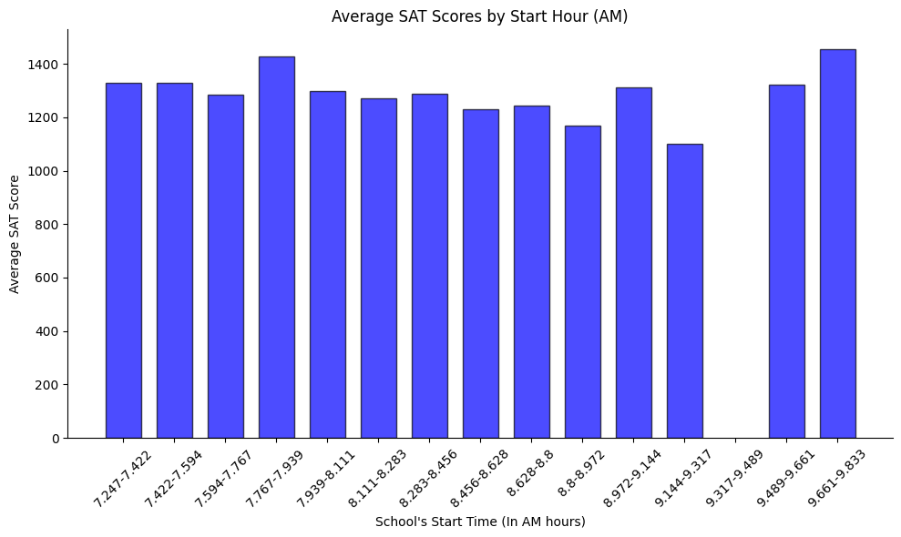

```python
student_bins = pd.cut(scores_df['Start Time Hour'], bins=15)

# Grouping by the bins
binned_avg_sat = scores_df.groupby(student_bins)['Average Total SAT Score'].mean()

#edges of each bin for labeling
bin_edges = student_bins.cat.categories


plt.figure(figsize=(10, 6))
plt.bar(range(len(binned_avg_sat)), binned_avg_sat, width=.7, alpha=0.7, color='blue', edgecolor='black')

# title and main lables
plt.title('Average SAT Scores by Start Hour (AM)')
plt.xlabel('School\'s Start Time (In AM hours)')
plt.ylabel('Average SAT Score')

# Labels
plt.xticks(ticks=np.arange(len(bin_edges)), labels=[f"{(edge.left)}-{(edge.right)}" for edge in bin_edges], rotation=45)
ax = plt.gca()
ax.spines['right'].set_visible(False)
ax.spines['top'].set_visible(False)

plt.tight_layout()  # Adjust the layout to make room for the x-axis labels
plt.show()


#I tried using ther other Hours column that was in time form but it would not work in the map.
```

I first want to look at the variable of start time since I wasn't able to in project one due to stuggles with date time formatting. The bar graph presents a quantitative comparison of average SAT scores across various school start times. The X-axis categorizes the data into hourly intervals of school start times, while the Y-axis represents the corresponding average total SAT scores achieved. I notice that from hour 7.7(7:42 AM) and 8.8(8:49AM), where most of our data present, I see a noticable decline in Average total SAT scores. So a start time of around 7:45-8am seems to be a good sweet spot. The trend tapers off as we get into earlier start times. However the trade off with starting earlier is that kids hate it.

Note: I can't change the x axis unit into times due to times not being able to be calculated in python. Even after many colaboration hours, this is the best soltuion that seems to be possible.

## 2.2 Maps and Interpretations

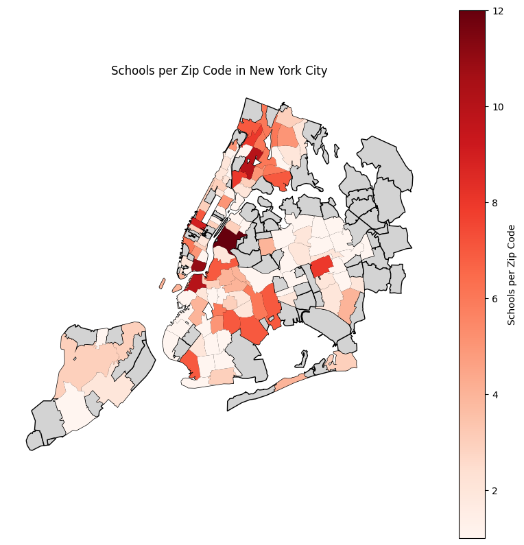

```python
import geopandas as gpd
school_counts = scores_df.groupby('Zip Code')['School ID'].nunique().reset_index(name='Schools per Zip Code')
scores_df = scores_df.merge(school_counts, on='Zip Code', how='left')
zip_codes_gdf = gpd.read_file("http://www2.census.gov/geo/tiger/GENZ2014/shp/cb_2014_us_zcta510_500k.zip")
nyc_zip_code_prefixes = ('100', '101', '102', '103', '104', '110', '111', '112', '113', '114', '116')
nyc_zip_codes_gdf = zip_codes_gdf[zip_codes_gdf['GEOID10'].str.startswith(nyc_zip_code_prefixes)]
# Calculate average SAT scores (Math, Reading, Writing) for each zip code
average_scores_by_zip = scores_df.groupby('Zip Code')['Schools per Zip Code'].mean().reset_index()
nyc_zip_codes_gdf = zip_codes_gdf[zip_codes_gdf['GEOID10'].str.startswith(nyc_zip_code_prefixes)]
# Merge the average scores data with the geographic data
average_scores_by_zip['Zip Code'] = average_scores_by_zip['Zip Code'].astype(str)
nyc_zip_codes_scores_gdf = nyc_zip_codes_gdf.merge(average_scores_by_zip, left_on='GEOID10', right_on='Zip Code', how='left')
nyc_zip_codes_scores_gdf = nyc_zip_codes_scores_gdf.set_geometry('geometry')
# Set up the figure and axis
fig, ax = plt.subplots(figsize=(10, 10))
# Plot the zip codes
nyc_zip_codes_scores_gdf.plot(ax=ax, color= 'lightgrey', edgecolor='black')

# Plot the average scores, using a colormap
nyc_zip_codes_scores_gdf.dropna(subset=['Schools per Zip Code']).plot(
    ax=ax,
    column='Schools per Zip Code', # Column to base the colors on
    cmap='Reds', # Colormap for different average scores
    legend=True, # To show a color bar legend
    legend_kwds={'label': "Schools per Zip Code"}, # Legend label
    missing_kwds={'color': 'lightgrey'},# Color for missing values
)

ax.axis('off')
ax.set_axis_off()
ax.set_title('Schools per Zip Code in New York City')
# Show the map
plt.show()
```

The map provides a visual representation of the distribution of schools across various zip codes in New York City. A significant number of zip codes contain at least one school. This indicates that characteristics of zip codes could be analyzed to understand the impact of a school's environment on SAT scores.

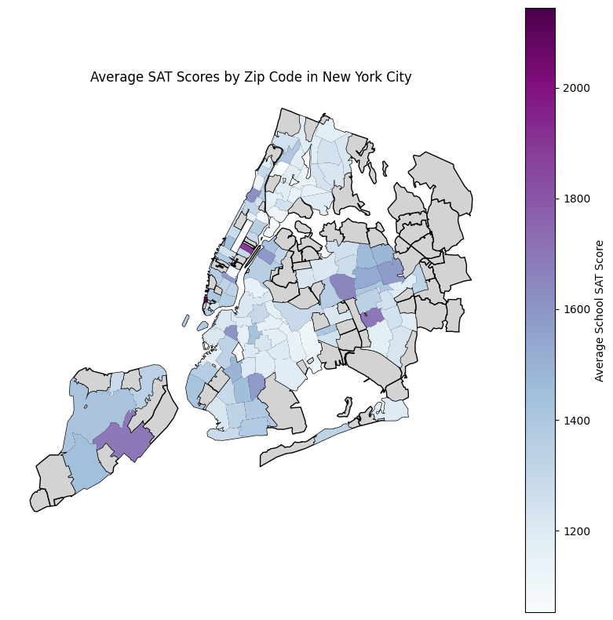

```python
# Filter schools data for New York City zip codes
nyc_zip_code_prefixes = ('100', '101', '102', '103', '104', '110', '111', '112', '113', '114', '116')
nyc_zip_codes_gdf = zip_codes_gdf[zip_codes_gdf['GEOID10'].str.startswith(nyc_zip_code_prefixes)]

# Calculate average SAT scores (Math, Reading, Writing) for each zip code

average_scores_by_zip = scores_df.groupby('Zip Code')['Average Total SAT Score'].mean().reset_index()



# Filter for New York City zip codes
nyc_zip_codes_gdf = zip_codes_gdf[zip_codes_gdf['GEOID10'].str.startswith(nyc_zip_code_prefixes)]

# Merge the average scores data with the geographic data
average_scores_by_zip['Zip Code'] = average_scores_by_zip['Zip Code'].astype(str)


nyc_zip_codes_scores_gdf = nyc_zip_codes_gdf.merge(average_scores_by_zip, left_on='GEOID10', right_on='Zip Code', how='left')

nyc_zip_codes_scores_gdf = nyc_zip_codes_scores_gdf.set_geometry('geometry')

# Set up the figure and axis
fig, ax = plt.subplots(figsize=(10, 10))

# Plot the zip codes
nyc_zip_codes_scores_gdf.plot(ax=ax, color= 'lightgrey', edgecolor='black')

# Plot the average scores, using a colormap
nyc_zip_codes_scores_gdf.dropna(subset=['Average Total SAT Score']).plot(
    ax=ax,
    column='Average Total SAT Score', # Column to base the colors on
    cmap='BuPu', # Colormap for different average scores
    legend=True, # To show a color bar legend
    legend_kwds={'label': "Average School SAT Score"}, # Legend label
    missing_kwds={'color': 'lightgrey'},# Color for missing values

)

# Remove the axis for a cleaner look
ax.axis('off')
ax.set_axis_off()
ax.set_title('Average SAT Scores by Zip Code in New York City')

# Show the map
plt.show()
```

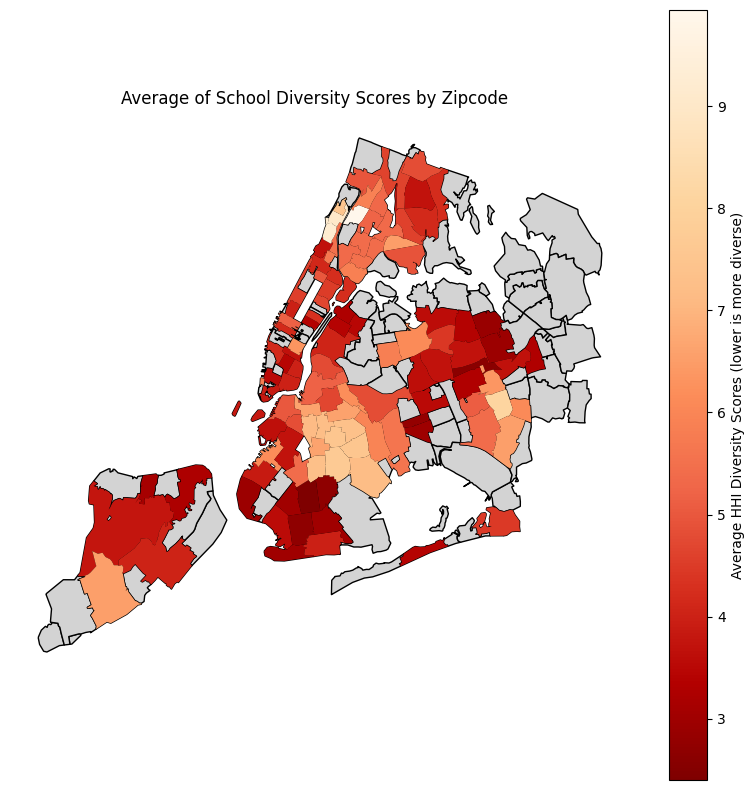

```python
# Calculate average HHI for each zip code
average_scores_by_zip = scores_df.groupby('Zip Code')['HHI'].mean().reset_index()

# Filter for New York City zip codes
nyc_zip_codes_gdf = zip_codes_gdf[zip_codes_gdf['GEOID10'].str.startswith(nyc_zip_code_prefixes)]

# Merge the average scores data with the geographic data
average_scores_by_zip['Zip Code'] = average_scores_by_zip['Zip Code'].astype(str)


nyc_zip_codes_scores_gdf = nyc_zip_codes_gdf.merge(average_scores_by_zip, left_on='GEOID10', right_on='Zip Code', how='left')

nyc_zip_codes_scores_gdf = nyc_zip_codes_scores_gdf.set_geometry('geometry')

# Set up the figure and axis
fig, ax = plt.subplots(figsize=(10, 10))

# Plot the zip codes
nyc_zip_codes_scores_gdf.plot(ax=ax, color='lightgrey', edgecolor='black')

# Plot the average scores, using a colormap
nyc_zip_codes_scores_gdf.dropna(subset=['HHI']).plot(
    ax=ax,
    column='HHI', # Column to base the colors on
    cmap='OrRd_r', # Colormap for different average scores
    legend=True, # To show a color bar legend
    legend_kwds={'label': "Average HHI Diversity Scores (lower is more diverse)"}, # Legend label
    missing_kwds={'color': 'lightgrey'} # Color for missing values
)

# Remove the axis for a cleaner look
ax.axis('off')
ax = plt.gca()
ax.spines['right'].set_visible(False)
ax.spines['top'].set_visible(False)
ax.set_title('Average of School Diversity Scores by Zipcode  ')

# Show the map
plt.show()
```

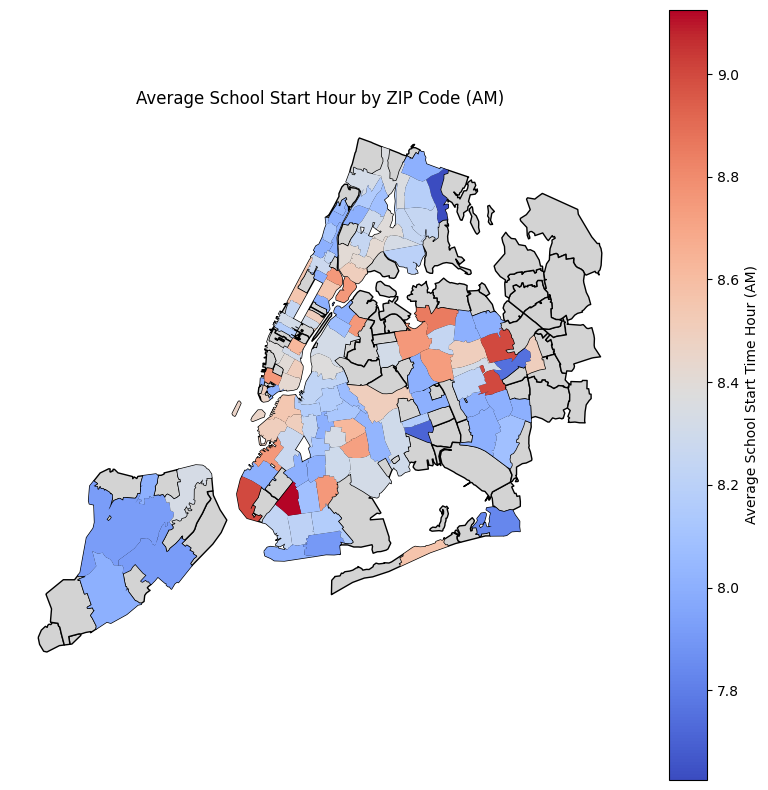

```python
# Calculate average SAT scores (Math, Reading, Writing) for each zip code

average_scores_by_zip = scores_df.groupby('Zip Code')['Start Time Hour'].mean().reset_index()

# Load the zip code shapefile


# Filter for New York City zip codes
nyc_zip_codes_gdf = zip_codes_gdf[zip_codes_gdf['GEOID10'].str.startswith(nyc_zip_code_prefixes)]

# Merge the average scores data with the geographic data
average_scores_by_zip['Zip Code'] = average_scores_by_zip['Zip Code'].astype(str)

# Now try merging again
nyc_zip_codes_scores_gdf = nyc_zip_codes_gdf.merge(average_scores_by_zip, left_on='GEOID10', right_on='Zip Code', how='left')

nyc_zip_codes_scores_gdf = nyc_zip_codes_scores_gdf.set_geometry('geometry')

# Set up the figure and axis
fig, ax = plt.subplots(figsize=(10, 10))

# Plot the zip codes
nyc_zip_codes_scores_gdf.plot(ax=ax, color='lightgrey', edgecolor='black')

# Plot the average scores, using a colormap
nyc_zip_codes_scores_gdf.dropna(subset=['Start Time Hour']).plot(
    ax=ax,
    column='Start Time Hour', # Column to base the colors on
    cmap='coolwarm', # Colormap for different average scores
    legend=True, # To show a color bar legend
    legend_kwds={'label': "Average School Start Time Hour (AM)"}, # Legend label
    missing_kwds={'color': 'lightgrey'} # Color for missing values
)

# Remove the axis for a cleaner look
ax.axis('off')
ax = plt.gca()
ax.spines['right'].set_visible(False)
ax.spines['top'].set_visible(False)
ax.set_title('Average School Start Hour by ZIP Code (AM)')
# Show the map
plt.show()
```

This map displays the average school start time by ZIP code. There is significant variation within neighboring areas, but one interesting observation is that some areas like Lower Brooklyn, Eastern Queens, and Manhattan, which had higher SAT scores, had school start times later in the morning, closer to 8:30. Conversely, the Band in Northern Brooklyn and Western Queens, characterized by lower SAT scores, had start times closer to 8 AM. This observation is contrary to what we might expect based on an earlier graph I created, where schools that started earlier, at 8 AM, tended to have higher scores than those that started later. Also, note that on any given day, all locations will experience sunrise within two minutes of each other, which is negligible compared to the roughly 45-minute to 1-hour difference in school start times we see here.

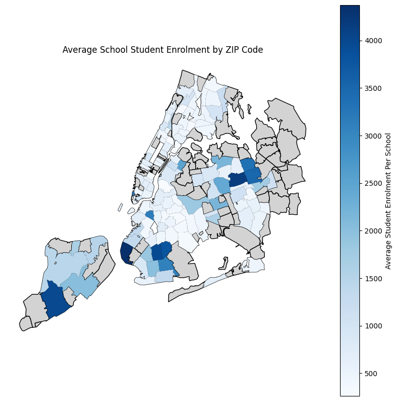

```python
# Calculate average SAT scores (Math, Reading, Writing) for each zip code

average_scores_by_zip = scores_df.groupby('Zip Code')['Student Enrollment'].mean().reset_index()

nyc_zip_codes_gdf = zip_codes_gdf[zip_codes_gdf['GEOID10'].str.startswith(nyc_zip_code_prefixes)]

# Merge the average scores data with the geographic data
average_scores_by_zip['Zip Code'] = average_scores_by_zip['Zip Code'].astype(str)

# Now try merging again
nyc_zip_codes_scores_gdf = nyc_zip_codes_gdf.merge(average_scores_by_zip, left_on='GEOID10', right_on='Zip Code', how='left')

nyc_zip_codes_scores_gdf = nyc_zip_codes_scores_gdf.set_geometry('geometry')

# Set up the figure and axis
fig, ax = plt.subplots(figsize=(10, 10))

# Plot the zip codes
nyc_zip_codes_scores_gdf.plot(ax=ax, color='lightgrey', edgecolor='black')

# Plot the average scores, using a colormap
nyc_zip_codes_scores_gdf.dropna(subset=['Student Enrollment']).plot(
    ax=ax,
    column='Student Enrollment', # Column to base the colors on
    cmap='Blues', # Colormap for different average scores
    legend=True, # To show a color bar legend
    legend_kwds={'label': "Average Student Enrolment Per School"}, # Legend label
    missing_kwds={'color': 'lightgrey'} # Color for missing values
)

# Remove the axis for a cleaner look
ax.axis('off')
ax.set_title('Average School Student Enrolment by ZIP Code')

# Show the map
plt.show()
```

Here is a map of the average school enrollment sizes. Right away, I observe that Manhattan and the Bronx have small school enrollment sizes. It is immediately apparent that certain areas, such as Manhattan and the Bronx, exhibit smaller average enrollment sizes. A particularly noteworthy observation is that the Band is very pronounced characterized by smaller enrollment sizes. Overall, areas with small enrollment sizes are seen to have lower scores, while areas with larger enrollment, such as Queens and Brooklyn, have higher enrollment sizes. This agrees with the graph from project 1.

# Project 3

## 3.1 Potential Data to Scrape

From Project 2, I gained a greater understanding of what may affect the average SAT score beyond the amount of preparation time. However, I have found some datasets with the locations of trees and fast food restaurants. To analyze this data, I found two datasets to scrape: one for population per zipcode and the other for land area per zipcode. I can use these to analyze the densities of trees and restaurants among other x variables. This will allow us to gain a deeper understanding of how x-variables affect SAT scores and, hopefully, we can establish some causality.

## 3.2 Potential Challenges

Challenges in web scraping can range from encountering paywalls for access to information, facing restrictions imposed by websites against data extraction, to the sheer volume of data that could make the scraping process excessively time-consuming. Furtheremore some data can be incomplete for my data set and therefore will resut in me dropping values.

In my case, after extensie searching, the required data was readily accessible for scraping, and I fortunately did not encounter many of the aforementioned obstacles except for finding data of NYC zip code size as and I could only find data for Manhatten Island and none from the other four bourghs. This is an issue becuase my data set on NYC highschools is already very small at less than 400 schools. I want keep all schools avalible to analyse.

# 3.3 Scraping Data from a Website

First, we will scrape the data on zip code sizes.

```python
import requests
import pandas as pd
from bs4 import BeautifulSoup
url = 'https://gisgeography.com/new-york-city-zip-code-map/'   #this is the url that the table is in.
response = requests.get(url)
headers = {'User-Agent': 'Mozilla/5.0 (Windows NT 10.0; Win64; x64) AppleWebKit/537.36 (KHTML, like Gecko) Chrome/58.0.3029.110 Safari/537.3'}
response.status_code #200 means that we got a successful response.
```

```
200
```

```python
response = requests.get(url, headers=headers)
soup_obj = BeautifulSoup(response.content)
table = soup_obj.find('figure', class_='wp-block-table').find('table') #I used a different find_all arguments to find the data tables.
#In this case we use "figure" and "wp-block-table" to find the table. This is different from the exersize and the class example.


rows = table.find_all('tr')
zipdf = pd.DataFrame(columns=['Zip Code', 'Name', 'State', 'Population', 'Square Miles of Zipcode'])

# Extract data from each row and add to the DataFrame
ix = 0 #serves as a counter for the row
for row in rows[1:]:
    cells = row.find_all('td')  # Find all cell tags in the row
    zipcode = cells[0].text.strip() #here we are assighing our variables that will build our data frame with. We loop per column
    name = cells[1].text.strip()
    state = cells[2].text.strip() #here we are buildig an array to pass into zipdf.loc[ix]
    population = cells[3].text.strip()
    square_miles = cells[4].text.strip()

        # Append the array of data to the DataFrame
    zipdf.loc[ix] = [zipcode, name, state, population, square_miles]
    ix += 1 #increment the index to move to the next row and the loop will repeat the proscess.
# Remove the 'Population' column
zipdf = zipdf.drop(columns='Population')
```

Similarly I scraped data on zipcode populations.

```python
url = 'https://www.newyork-demographics.com/zip_codes_by_population'
response = requests.get(url)
headers = {'User-Agent': 'Mozilla/5.0 (Windows NT 10.0; Win64; x64) AppleWebKit/537.36 (KHTML, like Gecko) Chrome/58.0.3029.110 Safari/537.3'}
response.status_code #200 means that we got a successful response.
```

```
200
```

```python
response = requests.get(url, headers=headers)
soup_obj = BeautifulSoup(response.content)
table = soup_obj.find('table', class_='ranklist table')
#I used a different find_all arguments to find the data tables. Here the website used a ranklist table which is different from the exersize and the class example.

rows = table.find_all('tr')
zipdf2 = pd.DataFrame(columns=['rank','Zip Code', 'Population'])

# Extract data from each row and add to the DataFrame
ix = 0
for row in rows[1:]:
    cells = row.find_all('td')  # Find all cell tags in the row
    if len(cells) > 1:  # Make sure there are enough cells in the row
        # Extract zipcode and population from the cells
        rank = cells[0].text.strip()  #here we are assighing our variables that will build our data frame with. We loop per column
        zipcode = cells[1].text.strip()
        population = cells[2].text.strip()
        # Append the data to the list as a tuple

        zipdf2.loc[ix] = [rank, zipcode, population]
    ix += 1
zipdf2 = zipdf2.drop(columns='rank')
```

```python
table = soup_obj.find('table', class_='ranklist table')
#I used a different find_all arguments to find the data tables. Here the website used a ranklist table which is different from the exersize and the class example.

rows = table.find_all('tr')
zipdf2 = pd.DataFrame(columns=['rank','Zip Code', 'Population'])

# Extract data from each row and add to the DataFrame
ix = 0#This will be our counter for the row
for row in rows[1:]:
    cells = row.find_all('td')  # Find all cell tags in the row
    if len(cells) > 1:  # Make sure there are enough cells in the row
        # Extract zipcode and population from the cells
        rank = cells[0].text.strip()  #here we are assighing our variables that will build our data frame with. We loop per column
        zipcode = cells[1].text.strip()
        population = cells[2].text.strip()
        # Append the data to the list as a tuple

        zipdf2.loc[ix] = [rank, zipcode, population]
    ix += 1 #here we iterate through the rows to complete the table
zipdf2 = zipdf2.drop(columns='rank')
```

## 3.4 Visulising the scraoped Dataset

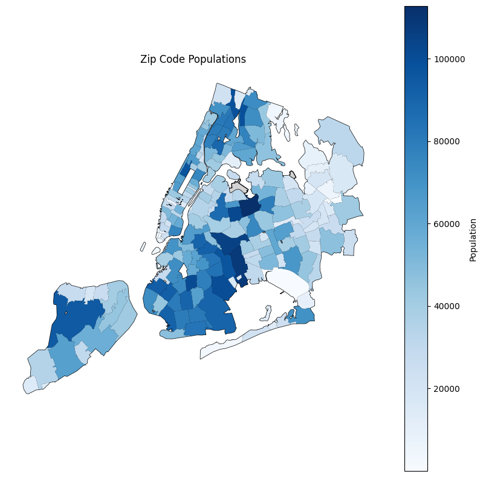

```python
zipdf2['Population'] = pd.to_numeric(zipdf2['Population'].str.replace(',', ''), errors='coerce')
zipdf2['Zip Code'] = zipdf2['Zip Code'].astype(str)
# Filter for New York City zip codes in the geographic data frame
average_scores_by_zip = zipdf2.groupby('Zip Code')['Population'].mean().reset_index()

# Filter for New York City zip codes
nyc_zip_codes_gdf = zip_codes_gdf[zip_codes_gdf['GEOID10'].str.startswith(nyc_zip_code_prefixes)]

# Merge the average scores data with the geographic data
average_scores_by_zip['Zip Code'] = average_scores_by_zip['Zip Code'].astype(str)
nyc_zip_codes_scores_gdf = nyc_zip_codes_gdf.merge(average_scores_by_zip, left_on='GEOID10', right_on='Zip Code', how='left')
nyc_zip_codes_scores_gdf = nyc_zip_codes_scores_gdf.set_geometry('geometry')
# Set up the figure and axis
fig, ax = plt.subplots(figsize=(10, 10))

ax.set_aspect('auto')
# Plot the base map for zip codes
nyc_zip_codes_scores_gdf.plot(ax=ax, color='lightgrey', edgecolor='black')
# Plot zip codes with population data using the 'Population' column for colors
nyc_zip_codes_scores_gdf.dropna(subset=['Population']).plot(
    ax=ax,
    column='Population', # Column to base the colors on
    cmap='Blues', # Colormap for different population sizes
    legend=True, # To show a color bar legend
    vmin = zipdf2["Population"].min(), vmax = zipdf2["Population"].max(),
    legend_kwds={'label': "Population"}, # Legend label for population


)
# Customize the plot
ax.axis('off')
ax.spines['right'].set_visible(False)
ax.spines['top'].set_visible(False)
ax.set_title('Zip Code Populations') # Optionally, you could add a title here
plt.show()
```

Here is a population map of New York City. I can see that Staten Island is not very densly populated. Also, Longisland gets less populated the further east we go. One thing to note is that Manhatten has very small zipcodes and that is why they appear lighter even though it is the most dence bourough. This map does confirm that there is a wide range of population dencities throughout NYC that we can use to study the population ratio to fast food restraunts and other potential x variables that we will merge in the next part.

## 3.5, adding new datasets

```python
#creating trees per zipcode variable
trees_df['Zip Code'] = trees_df['postcode'].astype(str).str.strip()
zipcode_counts = trees_df['Zip Code'].value_counts()
trees_df['num trees in zip'] = trees_df['Zip Code'].map(zipcode_counts)
trees_df = trees_df[trees_df['Zip Code'].str.startswith(tuple(nyc_zip_code_prefixes))]
```

```python
#filtering restraunts so that only nyc are included
zipcode_counts = restaurants_df['postalCode'].value_counts()

# Map this Series to a new column in your dataframe
# This will associate each restaurant with the count of restaurants in its ZIP code
restaurants_df['num_restaurants_in_zip'] = restaurants_df['postalCode'].map(zipcode_counts)


# Now, the dataframe has a new column with the number of restaurants in each ZIP code
nyc_zip_code_prefixes = ('100', '101', '102', '103', '104', '110', '111', '112', '113', '114', '116')
nyc_zip_codes_gdf = zip_codes_gdf[zip_codes_gdf['GEOID10'].str.startswith(nyc_zip_code_prefixes)]

# Calculate average SAT scores (Math, Reading, Writing) for each zip code
restaurants_df = restaurants_df[restaurants_df['postalCode'].str.startswith(tuple(nyc_zip_code_prefixes))]
restaurants_df = restaurants_df.rename(columns={'postalCode': 'Zip Code'})
# Assuming you have already calculated the number of restaurants per ZIP code in the `num_restaurants_in_zip` column
```

```python
#merging in trees data
scores_df['Zip Code'] = scores_df['Zip Code'].astype(str)
trees_df['Zip Code'] = trees_df['Zip Code'].astype(str)
# Now, let's say you want to merge a column named 'New Data' from df2 into df1
scores_df = scores_df.merge(trees_df[['Zip Code', 'num trees in zip']], on='Zip Code', how='left')
```

The below code merges in columns of the other data sets that are relevent. I don't want to merge the whole data set in for organisation and computation time purposes.

```python
#merging i everythign else
scores_df['Zip Code'] = scores_df['Zip Code'].astype(str)
trees_df['num trees in zip'] = trees_df['Zip Code'].map(zipcode_counts)
scores_df = scores_df.drop_duplicates(subset=['School ID'])
restaurants_df['Zip Code'] = restaurants_df['Zip Code'].astype(str)
scores_df = scores_df.merge(restaurants_df[['Zip Code', 'num_restaurants_in_zip']], on='Zip Code', how='left')
scores_df = scores_df.drop_duplicates(subset=['School ID'])
scores_df = scores_df.merge(zipdf[['Zip Code', 'Square Miles of Zipcode']], on='Zip Code', how='left')
scores_df = scores_df.drop_duplicates(subset=['School ID'])  #dropping duplicates at each step due to crashing even thoguht I got 16gb ram
scores_df = scores_df.merge(zipdf2[['Zip Code', 'Population']], on='Zip Code', how='left')
scores_df = scores_df.drop_duplicates(subset=['School ID'])
```

```python
school_food_df['School ID'] = school_food_df['DBN']
school_food_df = school_food_df[school_food_df['School ID'].isin(scores_df['School ID'])]
scores_df = scores_df.merge(school_food_df[['School ID', 'Lunches ADP', 'Salad bars']], on='School ID', how='left')
scores_df = scores_df.drop_duplicates(subset=['School ID'])
scores_df['num trees in zip'] = scores_df['num trees in zip']
```

The below code creates x variabels that we will study.

```python
scores_df['num_restaurants_in_zip'] = pd.to_numeric(scores_df['num_restaurants_in_zip'], errors='coerce').fillna(0)
scores_df['Population'] = pd.to_numeric(scores_df['Population'], errors='coerce').fillna(0)
scores_df['num trees in zip'] = pd.to_numeric(scores_df['num trees in zip'], errors='coerce').fillna(0)
scores_df['Square Miles of Zipcode'] = pd.to_numeric(scores_df['Square Miles of Zipcode'], errors='coerce').fillna(0)
scores_df['Lunches ADP'] = pd.to_numeric(scores_df['Lunches ADP'], errors='coerce').fillna(0)
scores_df['Salad bars'] = pd.to_numeric(scores_df['Salad bars'], errors='coerce').fillna(0)
scores_df['trees per square mile'] = scores_df['num trees in zip'] / scores_df['Square Miles of Zipcode']
scores_df['restaurants per square mile'] = scores_df['num_restaurants_in_zip'] / scores_df['Square Miles of Zipcode']
scores_df['restaurants per 10000 people'] = (scores_df['num_restaurants_in_zip'] / scores_df['Population']) * 10000
scores_df['Salad bars per 100 lunches served'] = scores_df['Salad bars'] * 100/ scores_df['Lunches ADP']
scores_df = scores_df.drop_duplicates(subset=['School ID'])
```

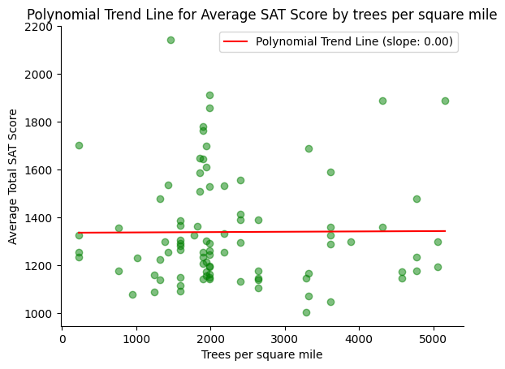

```python
scores_df_trees = scores_df.dropna(subset=['trees per square mile'])
scores_df_trees = scores_df_trees.replace([np.inf, -np.inf], np.nan).dropna()
plt.scatter(scores_df_trees['trees per square mile'], scores_df_trees['Average Total SAT Score'], alpha=0.5, color = 'green')
# Fit a polynomial of degree 3 (cubic) to the data
# Change the degree to fit the complexity of your data
degree = 1

coefficients = np.polyfit(scores_df_trees['trees per square mile'], scores_df_trees['Average Total SAT Score'], degree)
polynomial = np.poly1d(coefficients)
slope = coefficients[0]

# Generate a sequence of x values from the minimum to maximum total students for plotting
x_values = np.linspace(scores_df_trees['trees per square mile'].min(), scores_df_trees['trees per square mile'].max())

# Compute the y values from the polynomial
y_values = polynomial(x_values)

# Plot the polynomial trend line
plt.plot(x_values, y_values, color='red', label=f'Polynomial Trend Line (slope: {slope:.2f})')

# Add labels and title
plt.xlabel('Trees per square mile')
plt.ylabel('Average Total SAT Score')
plt.title('Polynomial Trend Line for Average SAT Score by trees per square mile')
plt.legend()
ax = plt.gca()
ax.spines['right'].set_visible(False)
ax.spines['top'].set_visible(False)

# Display the plot
plt.show()
```

In our graph above, which compares tree densities and SAT scores, our trend line shows a very slight upward slope. Clearly this will not be statisitcally signoficant. Although we have limited data on zip code size which results in many dropped variables, it doesn't make sense to study a tree-to-population ratio here. it is difficult to imagine a negative network externality from additional people congregating around trees. It makes more sense to analyze the density of trees, as this is what students will observe and potentially benefit from. As a result, with few data points, making a definitive conclusion about the hypothesis that more nature is beneficial is challenging for now.

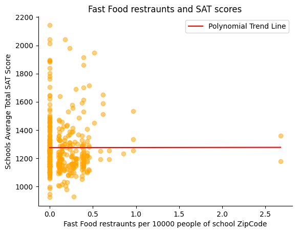

```python
scores_df = scores_df.dropna(subset=['restaurants per 10000 people'])
plt.scatter(scores_df['restaurants per 10000 people'], scores_df['Average Total SAT Score'], alpha=0.5, color = 'orange')
# Fit a polynomial of degree 3 (cubic) to the data
# Change the degree to fit the complexity of your data
degree = 1

coefficients = np.polyfit(scores_df['restaurants per 10000 people'], scores_df['Average Total SAT Score'], degree)
polynomial = np.poly1d(coefficients)

# Generate a sequence of x values from the minimum to maximum total students for plotting
x_values = np.linspace(scores_df['restaurants per 10000 people'].min(), scores_df['restaurants per 10000 people'].max(), num=100)

# Compute the y values from the polynomial
y_values = polynomial(x_values)

# Plot the polynomial trend line
plt.plot(x_values, y_values, color='red', label='Polynomial Trend Line')

# Add labels and title
plt.xlabel('Fast Food restraunts per 10000 people of school ZipCode')
plt.ylabel('Schools Average Total SAT Score')
plt.title('Fast Food restraunts and SAT scores')
plt.legend()
ax = plt.gca()
ax.spines['right'].set_visible(False)
ax.spines['top'].set_visible(False)

# Display the plot
plt.show()
```

Contrary to expectations, the presence of fast food restraunts don't seem to be correlated to SAT scores. possible reasons for this is that highschool students don't consume lots of fast food unless if it's a Friday night and one unhealthy meal per week may not have a significant affect on accademic performance. To analyse this variable, we could use a smaller level of geography measurment alongside a larger dataset. Furthermore, restaurents in a zipcode many not see many consumers from a school that is in the far corner of the same Zip Code.

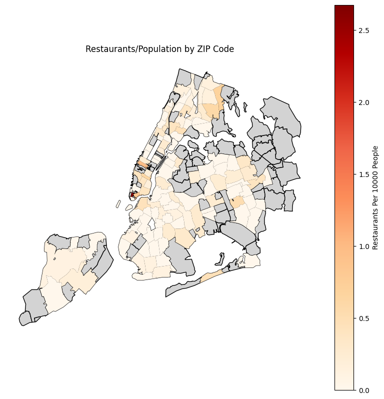

```python
average_scores_by_zip = scores_df.groupby('Zip Code')['restaurants per 10000 people'].mean().reset_index()

# Load the zip code shapefile


# Filter for New York City zip codes
nyc_zip_codes_gdf = zip_codes_gdf[zip_codes_gdf['GEOID10'].str.startswith(nyc_zip_code_prefixes)]

# Merge the average scores data with the geographic data
average_scores_by_zip['Zip Code'] = average_scores_by_zip['Zip Code'].astype(str)

# Now try merging again
nyc_zip_codes_scores_gdf = nyc_zip_codes_gdf.merge(average_scores_by_zip, left_on='GEOID10', right_on='Zip Code', how='left')

nyc_zip_codes_scores_gdf = nyc_zip_codes_scores_gdf.set_geometry('geometry')

# Set up the figure and axis
fig, ax = plt.subplots(figsize=(10, 10))

# Plot the zip codes
nyc_zip_codes_scores_gdf.plot(ax=ax, color='lightgrey', edgecolor='black')

# Plot the average scores, using a colormap
nyc_zip_codes_scores_gdf.dropna(subset=['restaurants per 10000 people']).plot(
    ax=ax,
    column='restaurants per 10000 people', # Column to base the colors on
    cmap='OrRd', # Colormap for different average scores
    legend=True, # To show a color bar legend
    legend_kwds={'label': "Restaurants Per 10000 People"}, # Legend label
    missing_kwds={'color': 'lightgrey'} # Color for missing values
)

# Remove the axis for a cleaner look
ax.axis('off')
ax = plt.gca()
ax.spines['right'].set_visible(False)
ax.spines['top'].set_visible(False)
ax.set_title('Restaurants/Population by ZIP Code')
# Show the map
plt.show()
```

This map shows the population and fast food restaurant ratios of zip codes which contain a high school that is in our study. We observe a higher density of fast food restaurants in the band compared to southern Brooklyn. Similarly, areas in the Bronx exhibit higher ratios. The number of fast food restaurants was lower than I anticipated. This suggests that it would be more informative to analyze the distance to the nearest fast food restaurant. This step will be absolutely necessary, especially given the limited data we possess. From a student's perspective, given the large sizes of zip codes, the utility derived from a fast food restaurant located on the far edge of a zip code is minimal, and students wouldn't consume from that restaurant.

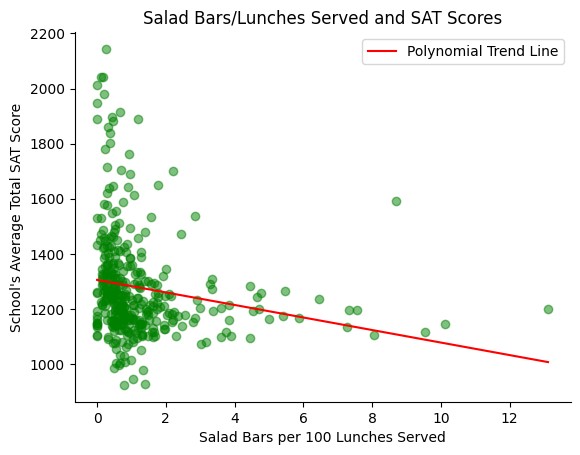

```python
scores_df3 = scores_df.dropna(subset=['Salad bars per 100 lunches served', 'Average Total SAT Score'])
plt.scatter(scores_df3['Salad bars per 100 lunches served'], scores_df3['Average Total SAT Score'], alpha=0.5, color = 'green')
# Fit a polynomial of degree 3 (cubic) to the data
# Change the degree to fit the complexity of your data
degree = 1

coefficients = np.polyfit(scores_df3['Salad bars per 100 lunches served'], scores_df3['Average Total SAT Score'], degree)
polynomial = np.poly1d(coefficients)

# Generate a sequence of x values from the minimum to maximum total students for plotting
x_values = np.linspace(scores_df3['Salad bars per 100 lunches served'].min(), scores_df3['Salad bars per 100 lunches served'].max(), num=100)

# Compute the y values from the polynomial
y_values = polynomial(x_values)

# Plot the polynomial trend line
plt.plot(x_values, y_values, color='red', label='Polynomial Trend Line')

# Add labels and title
plt.xlabel('Salad Bars per 100 Lunches Served')
plt.ylabel('School\'s Average Total SAT Score')
plt.title('Salad Bars/Lunches Served and SAT Scores')
plt.legend()
ax = plt.gca()
ax.spines['right'].set_visible(False)
ax.spines['top'].set_visible(False)

# Display the plot
plt.show()
```

Surprisingly, the number of salad bars per lunch served seems to have a negative correlation with SAT scores. There could be many confounding variables here. I recognize that not all salads are created equal. Many prefer dressings containing unhealthy hydrogenated oils and this expecially applies to kids as they have tendencies to make "healthy" things unhealthy and I was no expection this tendency when I was mini. We will need to study the number of salads that are served and the quality and quantity of toppings on the salads. Unfortunately, that data was not available in the merged data.

## OLS Regression

```python
from sklearn.preprocessing import StandardScaler
scaler = StandardScaler()
```

In project 1, sutdent enrollment seem linear. On the otherhand the time variables the HHI sudent diversity score do not.

For this ittertion of this project, I will study HHI, student enrolement, start time, and total daily shcool hours. HHI and student enrolment seem to have strong associations in project one. It seems that earlier start times results in hight SAT scores, but the map disagrees. Lastly I'd like to investigate daily time in school's lack of effect in SAT scores. The time variables and HHI diversity scores will be squared.

```python
info_dict={'R-squared' : lambda x: f"{x.rsquared:.2f}",
           'No. observations' : lambda x: f"{int(x.nobs):d}"}
```

```python
scores_df['const'] = 1
scores_df['Percent Asian'] = scores_df['Percent Asian']* 100
scores_df['Percent Black'] = scores_df['Percent Black']* 100
scores_df['Percent Hispanic'] = scores_df['Percent Hispanic']* 100
scores_df['Percent White'] = scores_df['Percent White']* 100
scores_df['HHI^2'] = scores_df['HHI'] ** 2
white_df = scores_df[scores_df['Percent White'] >= 25]
import statsmodels.api as sm
y = scores_df['Average Total SAT Score']
y_white = white_df['Average Total SAT Score']
X_white = white_df[['const', 'HHI', 'Percent White']]

X0 = ['const', 'HHI']
X = scores_df[['const', 'HHI','Percent Hispanic']]
X1 = ['const', 'HHI', 'Percent Asian']
X2 = ['const', 'HHI', 'Percent Black']
X3 = ['const', 'HHI', 'Percent White']
reg0 = sm.OLS(scores_df['Average Total SAT Score'], scores_df[X0], missing='drop').fit()
reg1 = sm.OLS(y, X).fit()
reg2 = sm.OLS(scores_df['Average Total SAT Score'], scores_df[X1], missing='drop').fit()
reg3 = sm.OLS(scores_df['Average Total SAT Score'], scores_df[X2], missing='drop').fit()
reg4 = sm.OLS(scores_df['Average Total SAT Score'], scores_df[X3], missing='drop').fit()
reg35 = sm.OLS(y_white, X_white, missing='drop').fit()
results_table = summary_col(results=[reg0,reg1,reg2,reg3,reg35,reg4],
                            float_format='%0.2f',
                            stars = True,
                            model_names=['model0','model1','Model 2','Model 3','model3.5','Model 4'],
                                 info_dict=info_dict,
                            regressor_order=['Average Total SAT Score','HHI','Percent Asian','Percent Black','Percent Hispanic'])
stargazer = Stargazer([reg0,reg1, reg2, reg3,reg4,reg35])
HTML(stargazer.render_html())
```

|  | *Dependent variable: Average Total SAT Score* |  |  |  |  |  |
| --- | --- | --- | --- | --- | --- | --- |
|  | (1) | (2) | (3) | (4) | (5) | (6) |
| HHI | -51.692*** | -43.433*** | -22.212*** | -44.283*** | -19.793*** | -84.726 |
|  | (5.693) | (5.416) | (5.522) | (5.974) | (5.540) | (92.041) |
| Percent Asian |  |  | 7.092*** |  |  |  |
|  |  |  | (0.616) |  |  |  |
| Percent Black |  |  |  | -1.355*** |  |  |
|  |  |  |  | (0.378) |  |  |
| Percent Hispanic |  | -2.690*** |  |  |  |  |
|  |  | (0.355) |  |  |  |  |
| Percent White |  |  |  |  | 7.928*** | 4.861 |
|  |  |  |  |  | (0.666) | (5.497) |
| const | 1533.195*** | 1610.179*** | 1312.301*** | 1544.196*** | 1306.493*** | 1648.963*** |
|  | (29.830) | (29.595) | (32.015) | (29.526) | (31.750) | (172.771) |
| Observations | 374 | 374 | 374 | 374 | 374 | 39 |
| R<sup>2</sup> | 0.181 | 0.291 | 0.397 | 0.209 | 0.408 | 0.024 |
| Adjusted R<sup>2</sup> | 0.179 | 0.287 | 0.394 | 0.205 | 0.405 | -0.030 |
| Residual Std. Error | 176.545 (df=372) | 164.507 (df=371) | 151.721 (df=371) | 173.799 (df=371) | 150.370 (df=371) | 228.973 (df=36) |
| F Statistic | 82.435*** (df=1; 372) | 76.186*** (df=2; 371) | 122.154*** (df=2; 371) | 48.954*** (df=2; 371) | 127.704*** (df=2; 371) | 0.446 (df=2; 36) |
| Note: | *p<0.1; **p<0.05; ***p<0.01 |  |  |  |  |  |

Note: I decided to use normal HHI instead of HHI(^2) since I got stronger results in the form of lower Residual Std. Error and higher R(^2) with the linear model.

My prefered specication is the one in cokumn $$ avg SAT score = \beta_0 + \beta_1 \text{HHI} $$ After plugging in the coefficentes we get the folloing model.

$$ avg SAT score = 1533.195 + -51.692\text{HHI} $$

These results help me answer my research question because we see that increasing diversity can have a positive effect on learning through its positive relationship with SAT scores.

Next I will merge in a dataset containing zipcode incomes.

```python
scores_df['Zip Code'] = scores_df['Zip Code'].astype(str)
income_df['Zip Code'] = income_df['Zip_Code'].astype(str)
scores_df = scores_df.merge(income_df[['Zip Code', 'Median']], on='Zip Code', how='left')
scores_df = scores_df.drop_duplicates(subset=['School ID'])
scores_df['Median'] = pd.to_numeric(scores_df['Median'], errors='coerce').fillna(0)
```

Next we will take a look at Start times. From project 2 the relation between the two wern't very clear. I have created a spearate data frame which contains the subset schools that start at 8:30 or later to compare with the overall dataset.

```python
scores_df['Start Time Hour^2'] = scores_df['Start Time Hour'] ** 2
scores_df['School Day Length^2'] = scores_df['School Day Length'] ** 2
ldf = scores_df[scores_df['Start Time Hour'] >= 8.5]
scores_df['Longitude'].astype(float)
scores_df['Latitude'].astype(float)
X9 = ['const', 'Start Time Hour^2']
X10 = ['const', 'Start Time Hour^2', 'School Day Length^2']
#school day length and start time hour square that.
# Estimate an OLS regression for each set of variables
reg9 = sm.OLS(ldf['Average Total SAT Score'], ldf[X9], missing='drop').fit()
reg10 = sm.OLS(ldf['Average Total SAT Score'], ldf[X10], missing='drop').fit()
reg11 = sm.OLS(scores_df['Average Total SAT Score'], scores_df[X9], missing='drop').fit()
reg12 = sm.OLS(scores_df['Average Total SAT Score'], scores_df[X10], missing='drop').fit()
results_table = summary_col(results=[reg9,reg10,reg11,reg12],
                            float_format='%0.2f',
                            stars = True,
                            model_names=['Model 1',
                                         'Model 2',
                                         'Model 3',
                                         'Model 4'],
                            info_dict=info_dict,
                            regressor_order=['Average Total SAT Score',
                                             'School Day Length^2'])
stargazer = Stargazer([reg9, reg10, reg11,reg12])
HTML(stargazer.render_html())
```

|  | *Dependent variable: Average Total SAT Score* |  |  |  |
| --- | --- | --- | --- | --- |
|  | (1) | (2) | (3) | (4) |
| School Day Length^2 |  | -1.716 |  | -1.663 |
|  |  | (2.499) |  | (1.471) |
| Start Time Hour^2 | 5.678 | 5.087 | -2.709* | -3.477** |
|  | (3.698) | (3.804) | (1.620) | (1.756) |
| const | 816.335*** | 940.731*** | 1461.211*** | 1596.482*** |
|  | (279.640) | (333.669) | (111.580) | (163.595) |
| Observations | 132 | 132 | 374 | 374 |
| R<sup>2</sup> | 0.018 | 0.021 | 0.007 | 0.011 |
| Adjusted R<sup>2</sup> | 0.010 | 0.006 | 0.005 | 0.006 |
| Residual Std. Error | 177.845 (df=130) | 178.208 (df=129) | 194.398 (df=372) | 194.326 (df=371) |
| F Statistic | 2.358 (df=1; 130) | 1.410 (df=2; 129) | 2.797* (df=1; 372) | 2.039 (df=2; 371) |
| Note: | *p<0.1; **p<0.05; ***p<0.01 |  |  |  |

we observe four regressions analyzing school start times. Columns one and two look at schools that start at 8:30 or later. Columns 3 and 4 look at the full data. For all start times, we see that there is a significant negative correlation as the day progresses. However, this is not the case for schools starting later in the day; the coefficient for start times post-8:30 am is not significant. Additionally, the School Day Length coefficient is negative for both the overall group and the late-start subset. This suggests that an earlier start time positively impacts academic performance, especially for early starters. On the otherhand, Overall utility gained form a longer school day is negative since time is a valuable resource. Instead of wasting time in school with no benefit to scores, time can be used on other activites such as time with family, and outdoor activites that provide positive utility rather than no utitlity at all.

My prefered specication is the one in column 4 as that regression contains all variables, and yet it also shows the suprising result that an increased School Day Length has no improvement to scores.

Our model is as follows $$ avg SAT score = \beta_0 + \beta_1 \text{Start Hour}^{2} + \beta_2 \text{School Hours}^{2} $$

After plugging in our regressions $$ avg SAT score = 1596.482 - 3.477\text{Start Hour}^{2} -1.663\text{School Hours}^{2} $$

These results help me answer my research question because we see that earlier can have a positive effect on learning through its positive relationship with SAT scores. Yet longer hours do not provide any positive effects.

Next I will study Student enrollment.

```python
scores_df_trees['const'] = 1
#median_income_dummies = pd.get_dummies(scores_df['Median'], prefix='MedianIncome')
scores_df['Start Time Hour^2'] = scores_df['Start Time Hour'] ** 2
scores_df['School Day Length^2'] = scores_df['School Day Length'] ** 2
# Create lists of variables to be used in each regression
X5 = ['const', 'Student Enrollment']
X6 = ['const', 'Student Enrollment', 'HHI']
X7 = ['const', 'Student Enrollment', 'HHI','Start Time Hour']
X8 = ['const', 'Student Enrollment','HHI', 'Start Time Hour', 'School Day Length']
# Estimate an OLS regression for each set of variables
reg5 = sm.OLS(scores_df['Average Total SAT Score'], scores_df[X5], missing='drop').fit()
reg6 = sm.OLS(scores_df['Average Total SAT Score'], scores_df[X6], missing='drop').fit()
reg7 = sm.OLS(scores_df['Average Total SAT Score'], scores_df[X7], missing='drop').fit()
reg8 = sm.OLS(scores_df['Average Total SAT Score'], scores_df[X8], missing='drop').fit()
#X6.extend(median_income_dummies.columns.tolist())
results_table = summary_col(results=[reg5,reg6,reg7,reg8],
                            float_format='%0.2f',
                            stars = True,
                            model_names=['Model 1','Model 2','Model 3','Model 4'],
                            info_dict=info_dict,
                            regressor_order=['Average Total SAT Score',
                                             'Student Enrolllement',
                                             'Percent Asian',
                                             'Percent Black',
                                             'Percent Hispanic'])
stargazer = Stargazer([reg5, reg6, reg7,reg8])
HTML(stargazer.render_html())
```

|  | *Dependent variable: Average Total SAT Score* |  |  |  |
| --- | --- | --- | --- | --- |
|  | (1) | (2) | (3) | (4) |
| HHI |  | -40.888*** | -42.046*** | -41.834*** |
|  |  | (5.689) | (5.651) | (5.736) |
| School Day Length |  |  |  | -4.199 |
|  |  |  |  | (18.590) |
| Start Time Hour |  |  | -65.642*** | -67.875*** |
|  |  |  | (23.321) | (25.359) |
| Student Enrollment | 0.100*** | 0.074*** | 0.074*** | 0.074*** |
|  | (0.012) | (0.012) | (0.012) | (0.012) |
| const | 1199.981*** | 1423.371*** | 1972.183*** | 2018.991*** |
|  | (12.962) | (33.373) | (197.761) | (286.635) |
| Observations | 374 | 374 | 374 | 374 |
| R<sup>2</sup> | 0.157 | 0.260 | 0.275 | 0.275 |
| Adjusted R<sup>2</sup> | 0.154 | 0.256 | 0.269 | 0.268 |
| Residual Std. Error | 179.187 (df=372) | 168.104 (df=371) | 166.558 (df=370) | 166.772 (df=369) |
| F Statistic | 69.133*** (df=1; 372) | 65.107*** (df=2; 371) | 46.855*** (df=3; 370) | 35.064*** (df=4; 369) |
| Note: | *p<0.1; **p<0.05; ***p<0.01 |  |  |  |

In the above table, All three regressions have significant positive coefficients for student enrollment. I added HHI and Start Time which also have significant results them selves as shown in the previous two regession tables. With all three of these combined, each of these variables have significance in the same direction as in the previous regressions. This was to look if all three of the variables togeather would give us the best results. The regression in column 4 was to see if the coefficent for school day length was still at or around 0, it's infact negative near 0. Even though this fact is interesting, this hardly contributes to the effictivness of the model. I will use the thrid regression in my model becuase it has the lowest RSE and the highest standard error out of all of them.

Economically, this model shows that not only student enrolment matters on its own, but diversity and earier start times seem work in tandem alongside increased student emrolment in improoving SAT scores. This sugestes that schols can work on diversity, earlier start times and student enrolnments at the same time.

To easily induce change in the three variables, city governments can goverments can pass bills that mandate diversity, enrollment, and start-time quotas for public schools.

It is also known that Higher incomes are assiciated with higher test scores. Here I will do a two-stage least squares regression. However as of right now there is no instruemntal variable in my datasets and this will take some greater searching and merging.

```python
# Fit the first stage regression and print summary
# results_fs = sm.OLS(scores_df['Median'],
                    #scores_df[['const', 'Average Total SAT Score']],
                    # missing='drop').fit()
# print(results_fs.summary())
```

```python
# scores_df['predicted_Median'] = results_fs.predict()

# results_ss = sm.OLS(scores_df['Average Total SAT Score'],
                    #scores_df[['const', 'predicted_Median']]).fit()
# print(results_ss.summary())
```

```python
#iv = IV2SLS(dependent=['Average Total SAT Score'],
            #exog=scores_df['const'],
            #endog=scores_df['Median'],
            #instruments=scores_df['predicted_Median']).fit(cov_type='unadjusted')

#print(iv.summary)
```

## Machine Learning

Using machine learning we should be able to improove out models obtianed from regressions. Our objective function is as follows $$ \min_{j,s} \left[ \sum_{i: x_{i,j} \leq s, x_i \in R1} (AS_i - \hat{AS}_{R1})^2 + \sum_{i: x_{i,j} > s, x_i \in R2} (AS_i - \hat{AS}_{R2})^2 \right] $$ where AS is a school's average Sat Score, and i and j are the indexes.

We also want to minimise the sum of the following which is the squared distances of the observed and the model. $$ (AS_i - \hat{AS}_{R1})^2 \quad \text{and} \quad (AS_i - \hat{AS}_{R2})^2 $$

A good prediction will minimise the sum the squared errors.

```python
X01 = scores_df[['HHI','Student Enrollment','Start Time Hour','School Day Length','Salad bars','restaurants per 10000 people','Start Time Hour',]]
X02 = scores_df[['Latitude','Longitude','HHI','Student Enrollment','Start Time Hour','School Day Length','Population','Salad bars','restaurants per 10000 people','Percent Tested','Percent Asian', 'Percent Black', 'Percent Hispanic', 'Percent White','End Time Hour','Median']]
y = scores_df['Average Total SAT Score']
```

Above, X01 consists of variables that we have studied. X02 on the otherhand has a wider range of variables which includes all X01. Due to the small dataset fo 374 highschools, I have removed variables where there are datapoints with missing data.

```python
#drop columns that are not needed
from sklearn import (linear_model, metrics, pipeline, model_selection)
from sklearn import linear_model
from sklearn import tree
from sklearn import linear_model

# construct the model instance
```

```python
lr_model = linear_model.LinearRegression()
lr_model.fit(X01, y)
y_pred_linear = lr_model.predict(X01)
from sklearn import metrics
full_mse = metrics.mean_squared_error(y, y_pred_linear)
print('Mean Squared Error for selected:', full_mse)
```

```
Mean Squared Error for selected: 27422.788119160206
```

Here, a regression tree is run with a depth of three. A higher depth can result in minimizing the MSE, but on the other hand, we get more nodes, which will make the tree more difficult to understand and less intuitive.

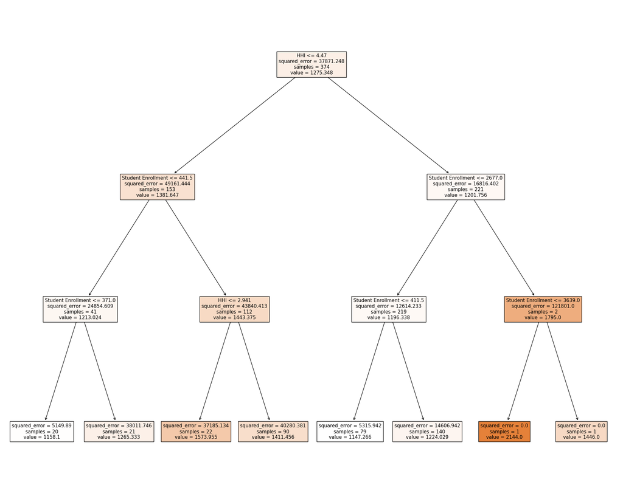

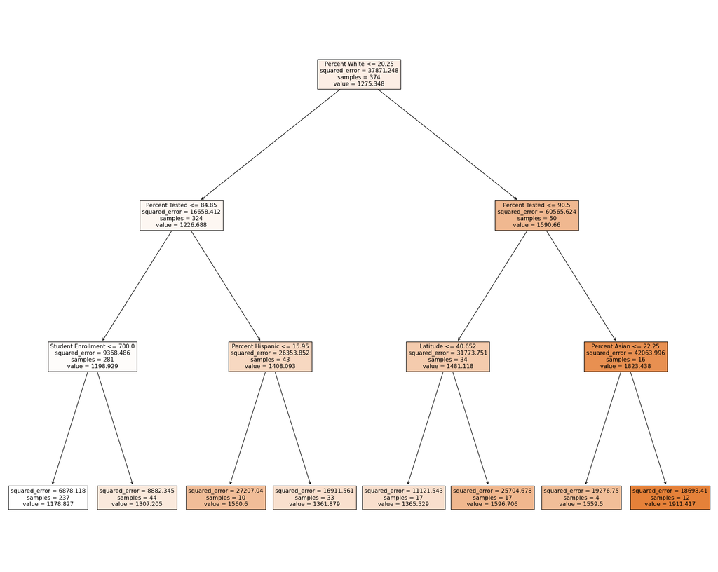

```python
from sklearn import tree
tree1 = tree.DecisionTreeRegressor(max_depth=3).fit(X01,y)
treefig1 = plt.figure(figsize=(25,20))
treefig1 = tree.plot_tree(tree1, feature_names=X01.columns, filled=True)
tree2 = tree.DecisionTreeRegressor(max_depth=3).fit(X02,y)
treefig2 = plt.figure(figsize=(25,20))
treefig2 = tree.plot_tree(tree2, feature_names=X02.columns, filled=True)
```

For the tree with all variables, including the ones we have not extensively studied, the tree is cut by student enrollment in the third layer. However, note that in that cut, we still had almost three-fourths of the data points in that node, which suggests that student enrollment is still a very important variable.

Overall, the squared error in the final nodes varies widely; however, the tree with more variables to split on does perform slightly better, and that was to be expected.

```
Mean Squared Error: 1278.7877163101605
```

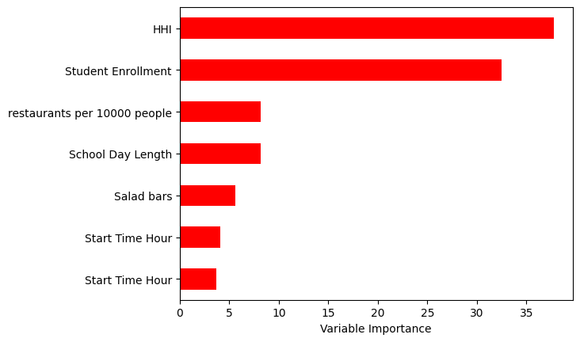

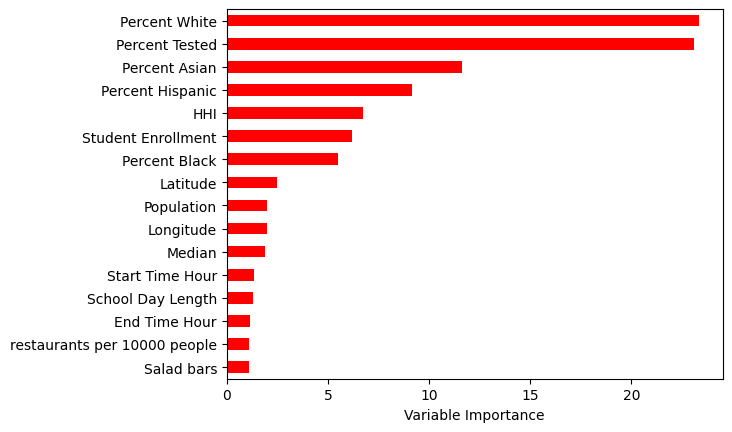

```python
from sklearn.ensemble import BaggingClassifier, RandomForestClassifier, BaggingRegressor, RandomForestRegressor, GradientBoostingRegressor
from sklearn.metrics import mean_squared_error,confusion_matrix, classification_report



regr_RF1 = RandomForestRegressor(max_features=5, random_state=1).fit(X01, y)
pred = regr_RF1.predict(X01)
#calculate MSE
mean_squared_error(y, pred)
Importance = pd.DataFrame({'Importance':regr_RF1.feature_importances_*100}, index=X01.columns)
Importance.sort_values('Importance', axis=0, ascending=True).plot(kind='barh', color='r', )
plt.xlabel('Variable Importance')
plt.gca().legend_ = None

for col in X02.columns:
    if pd.api.types.is_datetime64_any_dtype(X02[col]):
        X02[col] = X02[col].map(pd.Timestamp.timestamp)

# Now proceed with fitting the model as before
regr_RF2 = RandomForestRegressor(max_features=5, random_state=1).fit(X02, y)
pred2 = regr_RF2.predict(X02)
#calculate MSE
mse = mean_squared_error(y, pred2)
print('Mean Squared Error:', mse)

# Plotting feature importances
Importance2 = pd.DataFrame({'Importance': regr_RF2.feature_importances_*100}, index=X02.columns)
Importance2.sort_values('Importance', axis=0, ascending=True).plot(kind='barh', color='r',)
plt.xlabel('Variable Importance')
plt.gca().legend_ = None
plt.show()
```

In the above importance matrix, we see that the individual races matter more than overall diversity. This does point to the notion that there is a difference in performance across races, similar to what was seen in the regression table studying HHI. However, the HHI diversity score variable also has high importance, which suggests that diversity may mitigate inequality. Student enrollment is the second most important non-racial variable when looking at all quantifiable variables. Meanwhile, the variables looking at health, such as restaurants per 10,000 people and salad bars, saw very low importance in predicting SAT scores. It is important to note that these health variables have higher exposure to confounders than the variables coming from the primary scores dataset.

## Conclusion

All in all, we have uncovered some interesting insights on schools and their SAT scores. Most notably, racial diversity, school scheduals, and various health inducing variables were studied.

The variables measuring school start time, total school time, diversity, and enrollment were derived directly frojm the scores data set. Many of the results from project one and project two were suprising. Finally in the regression and machine learnign sections, the suprising results were shown to be significant.

Moreover, the five merged datasets added to this project that are thought to have health inducing effects have provided limited insights into the correlation between healthy lifestyles and SAT scores. It is predicted that this may be due to underlying confounding variables whcih we dont ahve the tools to control for. The next issue that we have is the extremely limited data set available. There are more health variables worth looking into available for merging and analysis, especially from https://www.schools.nyc.gov.

In the future, I hope to use more datapoints. If there is more data on schools from other cities and after controlling for city fixed effects, I may be able to get stronger results for the passive variabels that affect health. My goal is to improve the education experience by improving school enviorments that will maximise the utility from learning. There is the old saying "work smarter and not harder" and I will reasearch if these benefits from these heath variables could subsitute mental health counseling which costs money, time, and labour whilest not always being effective.

Bibliography:

Bayar, A., & Karaduman, H. A. (2021). The effects of school culture on students academic achievements. SHANLAX International Journal of Education, 9(3). Retrieved from https://files.eric.ed.gov/fulltext/EJ1300860.pdf

Berding, K., Carbia, C., & Cryan, J. F. (2021). Going with the grain: Fiber, cognition, and the microbiota-gut-brain-axis. Experimental Biology and Medicine, 246(7), 796–811. https://doi.org/10.1177/1535370221995785

Blume, C., Garbazza, C., & Spitschan, M. (2019). Effects of light on human circadian rhythms, sleep and mood. Somnologie, 23(3), 147-156. https://doi.org/10.1007/s11818-019-00215-x

Kuo, F. E., & Taylor, A. F. (2004). A Potential Natural Treatment for Attention-Deficit/Hyperactivity Disorder: Evidence From a National Study. American Journal of Public Health, 94(9), 1580–1586. https://doi.org/10.2105/ajph.94.9.1580

Lau, Y. (2022). Does Racial Diversity Improve Academic Outcomes? A Natural Experiment in Higher Education Classrooms. SSRN. https://doi.org/10.2139/ssrn.4173227

Purtell, K. M., & Gershoff, E. T. (2015). Fast Food Consumption and Academic Growth in Late Childhood. Clinical Pediatrics, 54(9), 871–877. https://doi.org/10.1177/0009922814561742

Song, C., Ikei, H., & Miyazaki, Y. (2016). Physiological Effects of Nature Therapy: A Review of the Research in Japan. International Journal of Environmental Research and Public Health, 13(8), 781. https://doi.org/10.3390/ijerph13080781

Ramchander, M., & Naude, M. J. (2018). The Relationship between Increasing Enrolment and Student Academic Achievement in Higher Education. Africa Education Review, 15(4), 135–151. https://doi.org/10.1080/18146627.2017.1340804